# BeatwiseTimeSeries

September 14, 2015

The beat and district numbers in the data were re-assigned by finding in which new beat/district polygon the point falls and then label that beat/district number. Therefore all violent crime beat and district records have a unified reference which is the new CPD beat/district map.

The evaluation date starts from 2014-01-01 and ends on 2014-12-31. The time series training uses preceding 12-year data (or windowed 12-year data) of the corresponding testing date.

Here shows an example of time series predictions’ and residuals’ distribution (last evaluation example).

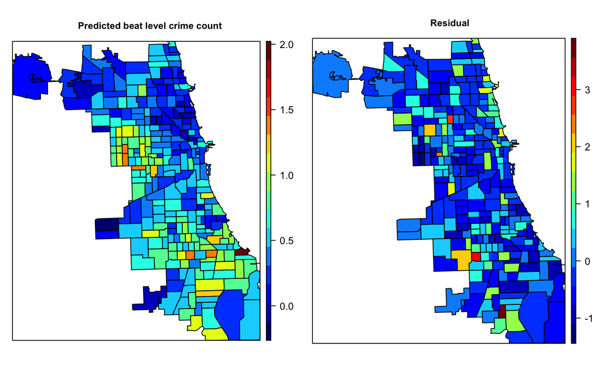

The evaluation is done through sensitivity(TPR)-like comparison between prediction model,long-term density and short-term density. To illustrate the idea, we demonstrate an example below the *sensitivity* plots: first selecting 10% highest pixels (threshold = 0.9 quantile of image histogram) then count how many actual crime incidents happened in these regions. And we do in this fashion for different threshold quantiles to get the *sensitivity* plot.

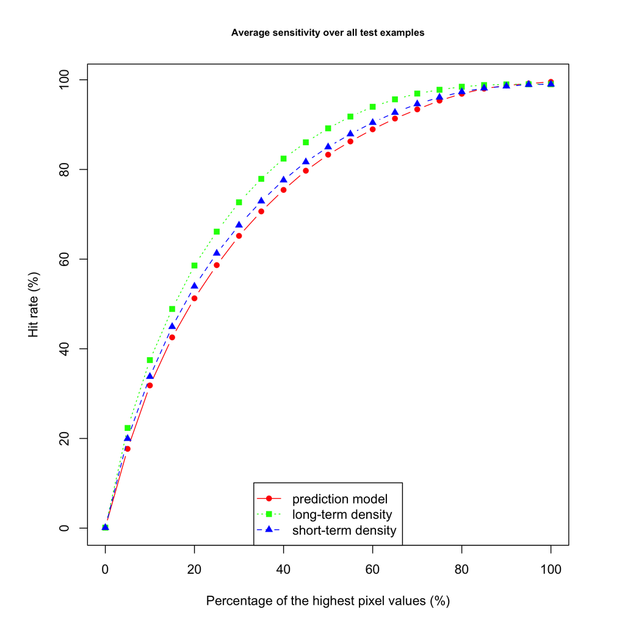

[figure not shown]

[figure not shown]

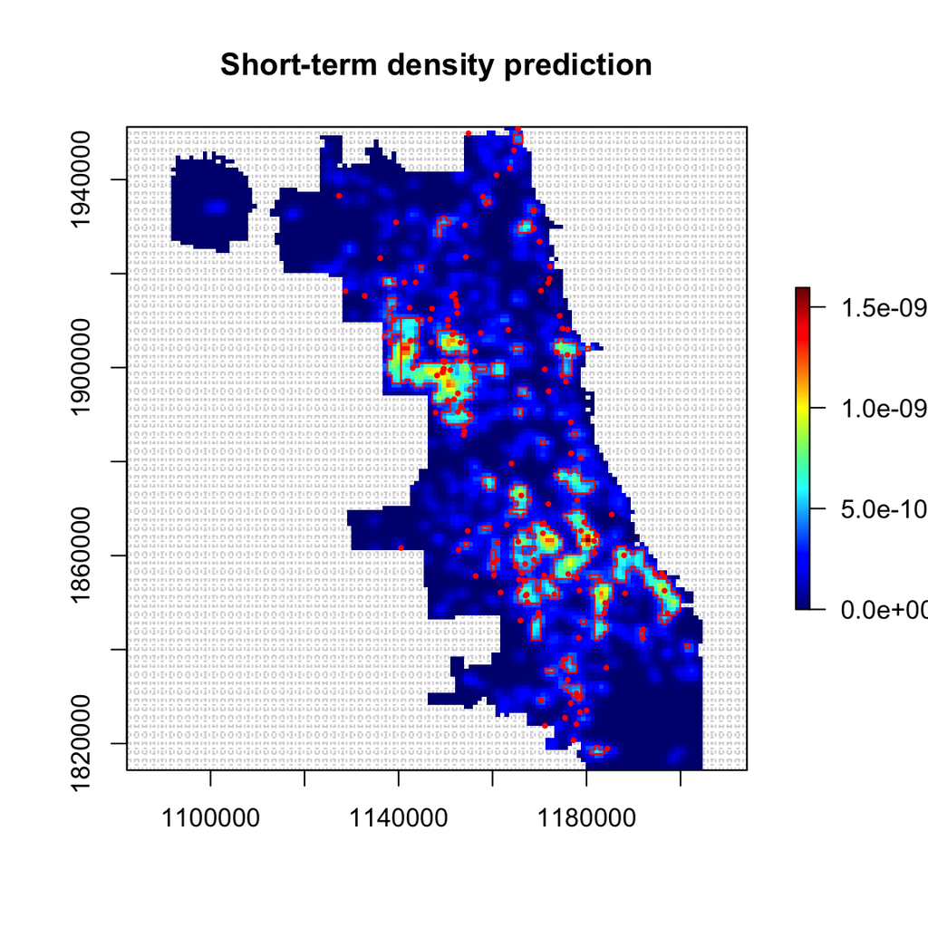